# Assigment MP_6

# Decompose the time series to verify trend and seasonality

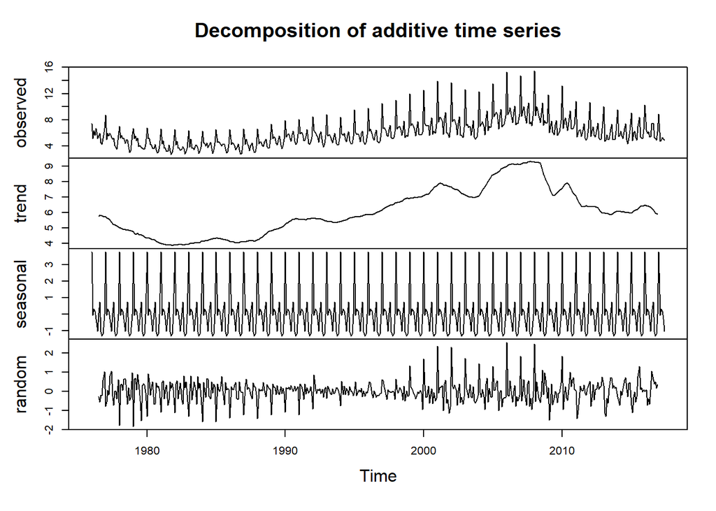

```r
decomp <- decompose(flightvolume_ts)
plot(decomp)
```

```r
decomp$type
```

```
## [1] "additive"
```

## 6.Choose an accuracy measure

- We’ll use Mean Absolute Error (MAE) and Root Mean Squared Error (RMSE) for model evaluation. later

## Naive model

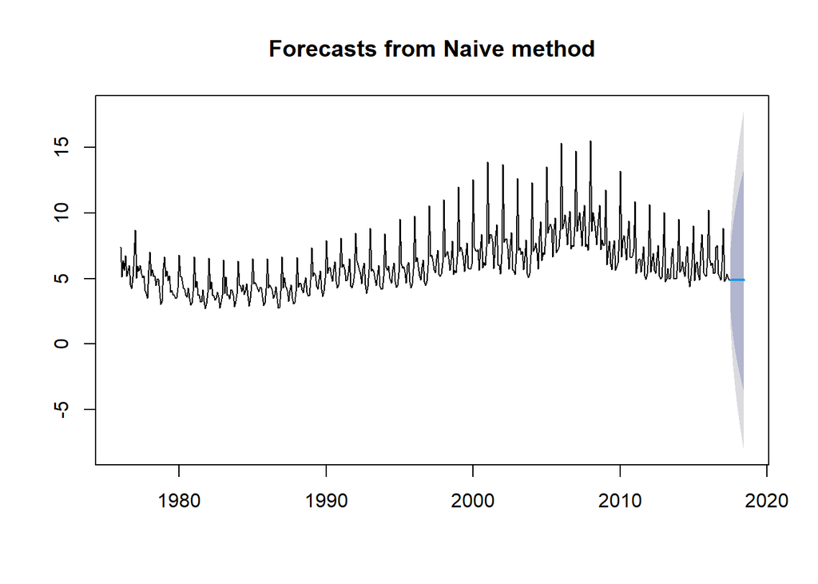

```r
naive_forecast <- naive(flightvolume_ts, h=12)
plot(naive_forecast)
```

##### Naive Method Summary

*The naive model simply assumes the future will be exactly like the most recent value (no trend or seasonality).

## Simple Moving Averages

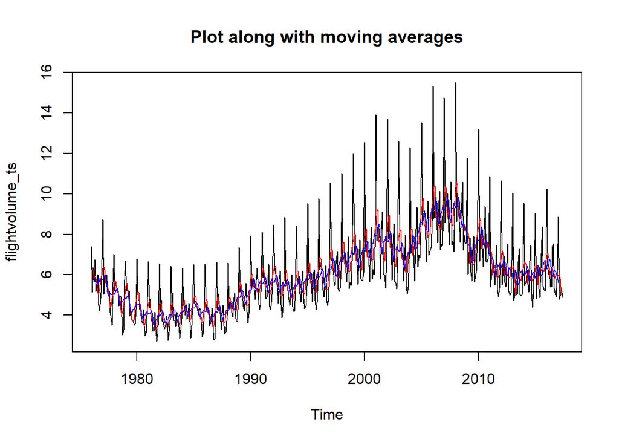

```r
MA5_forecast <- ma(flightvolume_ts,order=5)
MA9_forecast <- ma(flightvolume_ts,order=9)
plot(flightvolume_ts, main ="Plot along with moving averages")
lines(MA5_forecast,col="Red")
lines(MA9_forecast,col="Blue")
```

##### Observations

- The average model assumes the future will be the same as the historical average.
- From the plots, it is observed that the higher the order we consider, the smoother the moving average curve in the plot.
- It can be seen that the blue line above is the smoothest compared to Red line.
- The Red line (order 5) gives the most real data compared to the other line. The higher order averages smoother the plot and do not give the actual values.

## Exponential Smoothing Model (Simple Exponential Smoothing - SES)

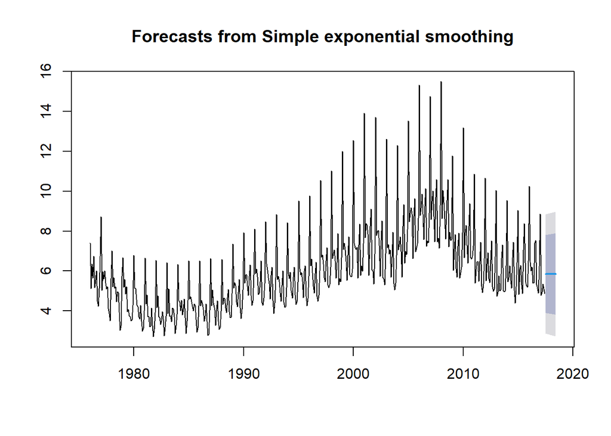

```r
ses_forecast <- ses(flightvolume_ts, h=12)
plot(ses_forecast)
```

```r
attributes(ses_forecast)
```

```
## $names
##  [1] "model"     "mean"      "level"     "x"         "upper"     "lower"
##  [7] "fitted"    "method"    "series"    "residuals"
##
## $class
## [1] "forecast"
```

##### Observations

- Exponential Smoothing gives more weight to recent observations, making it more responsive to changes.
- From 1990 to 2008 there is observed to be an increasing trend in the data. So, this forecast may not be a right way to forecast.